[figure not shown]

# Artificial Intelligence and Machine Learning

Project Python Foundations: FoodHub Data Analysis

[figure not shown]

### Context

The number of restaurants in New York is increasing day by day. Lots of students and busy professionals rely on those restaurants due to their hectic lifestyles. Online food delivery service is a great option for them. It provides them with good food from their favorite restaurants. A food aggregator company FoodHub offers access to multiple restaurants through a single smartphone app.

The app allows the restaurants to receive a direct online order from a customer. The app assigns a delivery person from the company to pick up the order after it is confirmed by the restaurant. The delivery person then uses the map to reach the restaurant and waits for the food package. Once the food package is handed over to the delivery person, he/she confirms the pick-up in the app and travels to the customer's location to deliver the food. The delivery person confirms the drop-off in the app after delivering the food package to the customer. The customer can rate the order in the app. The food aggregator earns money by collecting a fixed margin of the delivery order from the restaurants.

### Objective

The food aggregator company has stored the data of the different orders made by the registered customers in their online portal. They want to analyze the data to get a fair idea about the demand of different restaurants which will help them in enhancing their customer experience. Suppose you are hired as a Data Scientist in this company and the Data Science team has shared some of the key questions that need to be answered. Perform the data analysis to find answers to these questions that will help the company to improve the business.

### Data Description

The data contains the different data related to a food order. The detailed data dictionary is given below.

### Data Dictionary

- order_id: Unique ID of the order
- customer_id: ID of the customer who ordered the food
- restaurant_name: Name of the restaurant
- cuisine_type: Cuisine ordered by the customer
- cost_of_the_order: Cost of the order
- day_of_the_week: Indicates whether the order is placed on a weekday or weekend (The weekday is from Monday to Friday and the weekend is Saturday and Sunday)
- rating: Rating given by the customer out of 5
- food_preparation_time: Time (in minutes) taken by the restaurant to prepare the food. This is calculated by taking the difference between the timestamps of the restaurant's order confirmation and the delivery person's pick-up confirmation.
- delivery_time: Time (in minutes) taken by the delivery person to deliver the food package. This is calculated by taking the difference between the timestamps of the delivery person's pick-up confirmation and drop-off information

```python
# Installing the libraries with the specified version.
!pip install numpy==2.0.2 pandas==2.2.2 matplotlib==3.10.0 seaborn==0.13.2 -q --user
```

**Note**: After running the above cell, kindly restart the runtime and run all cells sequentially from the next cell.

```python
# import libraries for data manipulation
import numpy as np
import pandas as pd

# import libraries for data visualization
import matplotlib.pyplot as plt
import seaborn as sns
```

### Understanding the structure of the data

```python
# uncomment and run the below code snippets if the dataset is present in the Google Drive
from google.colab import drive
drive.mount('/content/drive')
```

```python
# Read the dataset from my drive
df = pd.read_csv('/content/drive/MyDrive/PGP-AI & ML/Projects/FoodHub Project #1/foodhub_order.csv')

# View first 5 rows of the data
df.head()
```

|  | order_id | customer_id | restaurant_name | cuisine_type | cost_of_the_order | day_of_the_week | rating | food_preparation_time | delivery_time |
| --- | --- | --- | --- | --- | --- | --- | --- | --- | --- |
| 0 | 1477147 | 337525 | Hangawi | Korean | 30.75 | Weekend | Not given | 25 | 20 |
| 1 | 1477685 | 358141 | Blue Ribbon Sushi Izakaya | Japanese | 12.08 | Weekend | Not given | 25 | 23 |
| 2 | 1477070 | 66393 | Cafe Habana | Mexican | 12.23 | Weekday | 5 | 23 | 28 |
| 3 | 1477334 | 106968 | Blue Ribbon Fried Chicken | American | 29.20 | Weekend | 3 | 25 | 15 |
| 4 | 1478249 | 76942 | Dirty Bird to Go | American | 11.59 | Weekday | 4 | 25 | 24 |

### **Question 1:** How many rows and columns are present in the data? [0.5 mark]

```python
# Shape of the dataset using the shape function
print('Number of rows and columns:', df.shape)
```

```
Number of rows and columns: (1898, 9)
```

#### Observations:

- The foodhub dataset contains 1,898 rows and 9 columns.
- Each row is a unique food order placed through the FoodHub platform.
- A total of 1,898 orders are in this dataset.

### **Question 2:** What are the datatypes of the different columns in the dataset? (The info() function can be used) [0.5 mark]

```python
# Data types of all columns
df.info()
```

```
<class 'pandas.core.frame.DataFrame'>
RangeIndex: 1898 entries, 0 to 1897
Data columns (total 9 columns):
 #   Column                 Non-Null Count  Dtype
---  ------                 --------------  -----
 0   order_id               1898 non-null   int64
 1   customer_id            1898 non-null   int64
 2   restaurant_name        1898 non-null   object
 3   cuisine_type           1898 non-null   object
 4   cost_of_the_order      1898 non-null   float64
 5   day_of_the_week        1898 non-null   object
 6   rating                 1898 non-null   object
 7   food_preparation_time  1898 non-null   int64
 8   delivery_time          1898 non-null   int64
dtypes: float64(1), int64(4), object(4)
memory usage: 133.6+ KB
```

#### Observations:

- The datatype for `order_id` and `customer_id` is an integer (unique identifiers).
- `restaurant_name`, `cuisine_type`, `day_of_the_week`, and `rating` are object/string datatypes.
- The datatype for `cost_of_the_order` is a float numeric.
- The datatype for `food_preparation_time` and `delivery_time` are integers (measured in minutes).
- When observing the first five rows of the dataset, we identify that the `rating` column has some values that are "Not given".
- Because of the lack of a numerical score the datatype for `rating` needs to be a string, even though some food orders were given a numerical rating.
- There are 1,898 non-null values in all datatypes accross the entire dataset.

### **Question 3:** Are there any missing values in the data? If yes, treat them using an appropriate method. [1 mark]

```python
# Check for missing values
print('Missing values per column:')
print(df.isnull().sum())
```

```
Missing values per column:
order_id                 0
customer_id              0
restaurant_name          0
cuisine_type             0
cost_of_the_order        0
day_of_the_week          0
rating                   0
food_preparation_time    0
delivery_time            0
dtype: int64
```

#### Observations:

- There are **no missing (NaN) values** in any column of the dataset.
- It is worth noting that on Question 2, we identified that `rating` has `Not given` in some of the entries. So although the function `.isnull()` calculates no missing values in the dataset, we know that some customers did not rate their experience.

### **Question 4:** Check the statistical summary of the data. What is the minimum, average, and maximum time it takes for food to be prepared once an order is placed? [2 marks]

```python
# Statistical summary of the dataset
df.describe(include ='all').T
```

|  | count | unique | top | freq | mean | std | min | 25% | 50% | 75% | max |
| --- | --- | --- | --- | --- | --- | --- | --- | --- | --- | --- | --- |
| order_id | 1898.0 | NaN | NaN | NaN | 1477495.5 | 548.049724 | 1476547.0 | 1477021.25 | 1477495.5 | 1477969.75 | 1478444.0 |
| customer_id | 1898.0 | NaN | NaN | NaN | 171168.478398 | 113698.139743 | 1311.0 | 77787.75 | 128600.0 | 270525.0 | 405334.0 |
| restaurant_name | 1898 | 178 | Shake Shack | 219 | NaN | NaN | NaN | NaN | NaN | NaN | NaN |
| cuisine_type | 1898 | 14 | American | 584 | NaN | NaN | NaN | NaN | NaN | NaN | NaN |
| cost_of_the_order | 1898.0 | NaN | NaN | NaN | 16.498851 | 7.483812 | 4.47 | 12.08 | 14.14 | 22.2975 | 35.41 |
| day_of_the_week | 1898 | 2 | Weekend | 1351 | NaN | NaN | NaN | NaN | NaN | NaN | NaN |
| rating | 1898 | 4 | Not given | 736 | NaN | NaN | NaN | NaN | NaN | NaN | NaN |
| food_preparation_time | 1898.0 | NaN | NaN | NaN | 27.37197 | 4.632481 | 20.0 | 23.0 | 27.0 | 31.0 | 35.0 |
| delivery_time | 1898.0 | NaN | NaN | NaN | 24.161749 | 4.972637 | 15.0 | 20.0 | 25.0 | 28.0 | 33.0 |

```python
# Specific stats for food_preparation_time
prep = df['food_preparation_time']
print(f'Minimum food preparation time : {prep.min()} minutes')
print(f'Average food preparation time : {prep.mean():.2f} minutes')
print(f'Maximum food preparation time : {prep.max()} minutes')
```

```
Minimum food preparation time : 20 minutes
Average food preparation time : 27.37 minutes
Maximum food preparation time : 35 minutes
```

#### Observations:

- **Minimum** food preparation time: **20 minutes**
- **Average** food preparation time: **~27.37 minutes**
- **Maximum** food preparation time: **35 minutes**
- The preparation times are fairly tightly distributed between 20 and 35 minutes, suggesting restaurants generally prepare food within a consistent window.

### **Question 5:** How many orders are not rated? [1 mark]

```python
# Count unrated orders
rating_counts = df['rating'].value_counts()
not_rated = (df['rating'] == 'Not given').sum()

print('Total of not rated orders:', not_rated)
print(f'Percentage of unrated orders: {not_rated / len(df) * 100:.2f}%')
```

```
Total of not rated orders: 736
Percentage of unrated orders: 38.78%
```

#### Observations:

- **736 orders** were not rated, which is approximately **38.78%** of all orders.
- This is a significant portion and may indicate customers who received their food but did not engage with the rating feature. This feedback gap is worth addressing to improve data quality.

### Exploratory Data Analysis (EDA)

### **Question 6:** Explore all the variables and provide observations on their distributions. (Generally, histograms, boxplots, countplots, etc. are used for univariate exploration.) [9 marks]

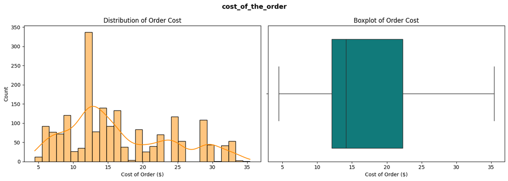

```python
# --- Numerical Variable: cost_of_the_order ---
fig, axes = plt.subplots(1, 2, figsize=(14, 5))
sns.histplot(df['cost_of_the_order'], bins=30, kde=True, ax=axes[0], color='darkorange')
axes[0].set_title('Distribution of Order Cost')
axes[0].set_xlabel('Cost of Order ($)')
sns.boxplot(x=df['cost_of_the_order'], ax=axes[1], color='darkcyan')
axes[1].set_title('Boxplot of Order Cost')
axes[1].set_xlabel('Cost of Order ($)')
plt.suptitle('cost_of_the_order', fontsize=13, fontweight='bold')
plt.tight_layout()
plt.show()
```

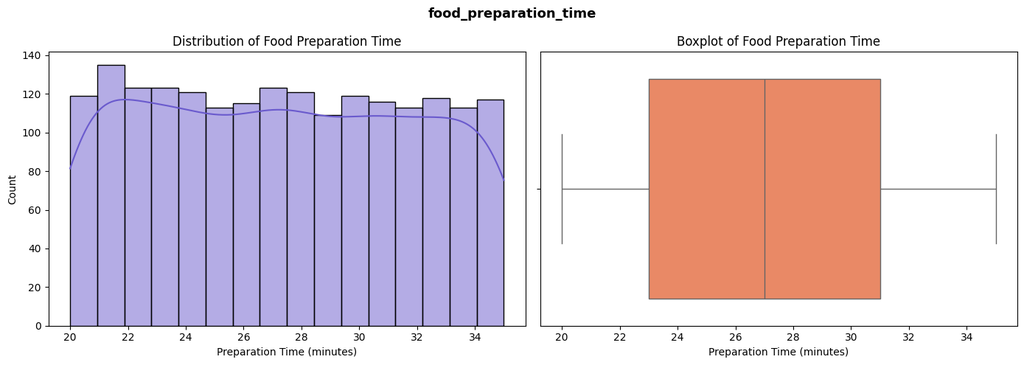

```python
# --- Numerical Variable: food_preparation_time ---
fig, axes = plt.subplots(1, 2, figsize=(14, 5))
sns.histplot(df['food_preparation_time'], bins=16, kde=True, ax=axes[0], color='slateblue')
axes[0].set_title('Distribution of Food Preparation Time')
axes[0].set_xlabel('Preparation Time (minutes)')
sns.boxplot(x=df['food_preparation_time'], ax=axes[1], color='coral')
axes[1].set_title('Boxplot of Food Preparation Time')
axes[1].set_xlabel('Preparation Time (minutes)')
plt.suptitle('food_preparation_time', fontsize=13, fontweight='bold')
plt.tight_layout()
plt.show()
```

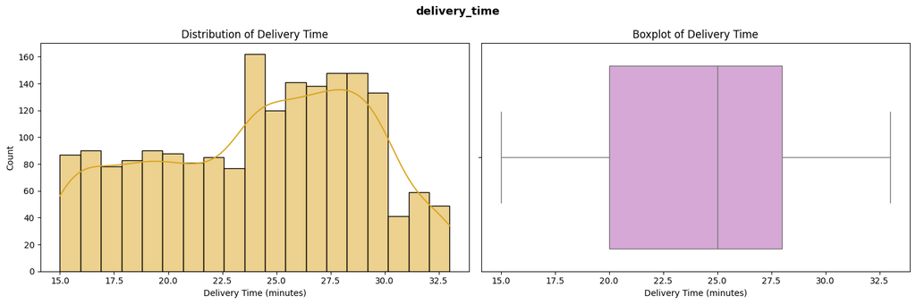

```python
# --- Numerical Variable: delivery_time ---
fig, axes = plt.subplots(1, 2, figsize=(15, 5))
sns.histplot(df['delivery_time'], bins=19, kde=True, ax=axes[0], color='goldenrod')
axes[0].set_title('Distribution of Delivery Time')
axes[0].set_xlabel('Delivery Time (minutes)')
sns.boxplot(x=df['delivery_time'], ax=axes[1], color='plum')
axes[1].set_title('Boxplot of Delivery Time')
axes[1].set_xlabel('Delivery Time (minutes)')
plt.suptitle('delivery_time', fontsize=13, fontweight='bold')
plt.tight_layout()
plt.show()
```

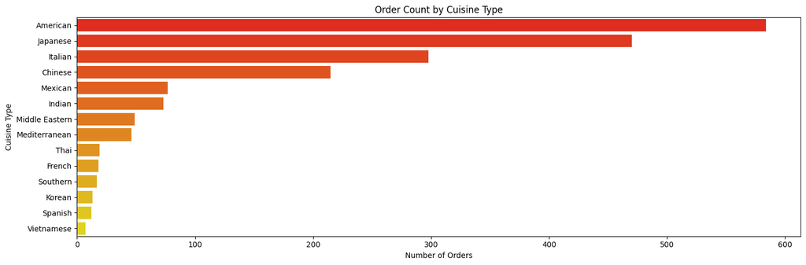

```python
# --- Categorical Variable: cuisine_type ---
# Had to import warnings because when I coded for hue I would get a FutureWarning error.
# This is due to the fact that seaborn assigns colors by category rather than by the position in the graph
# which in results breaks the gradient effect of my graph and does not represent the data correctly.
# I surpressed the warning so that it would not show up in my output
import warnings
warnings.filterwarnings('ignore', category=FutureWarning)

plt.figure(figsize=(15, 5))
order = df['cuisine_type'].value_counts().index
sns.countplot(data=df, y='cuisine_type', order=order, palette='autumn')
plt.title('Order Count by Cuisine Type')
plt.xlabel('Number of Orders')
plt.ylabel('Cuisine Type')
plt.tight_layout()
plt.show()
```

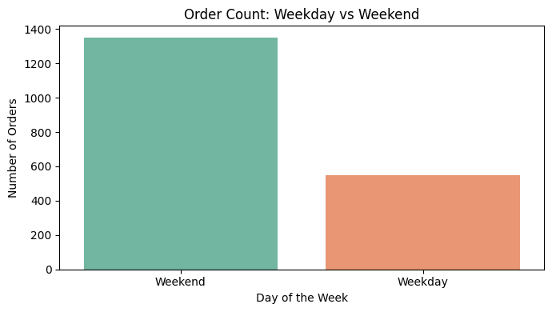

```python
 # --- Categorical Variable: day_of_the_week ---
plt.figure(figsize=(7, 4))
sns.countplot(data=df, x='day_of_the_week', hue= 'day_of_the_week', palette='Set2', legend=False)
plt.title('Order Count: Weekday vs Weekend')
plt.xlabel('Day of the Week')
plt.ylabel('Number of Orders')
plt.tight_layout()
plt.show()
```

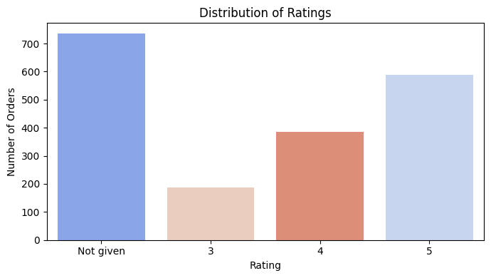

```python
# --- Categorical Variable: rating ---
plt.figure(figsize=(7, 4))
rating_order = ['Not given', '3', '4', '5']
sns.countplot(data=df, x='rating', order=rating_order, hue= 'rating', palette='coolwarm', legend=False)
plt.title('Distribution of Ratings')
plt.xlabel('Rating')
plt.ylabel('Number of Orders')
plt.tight_layout()
plt.show()
```

```python
# check unique order ID
unique_id = df['order_id'].nunique()
print('There are a total of', unique_id, 'unique IDs')
```

```
There are a total of 1898 unique IDs
```

```python
# check unique customer ID
unique_customer = df['customer_id'].nunique()
print('There are a total of', unique_customer,'unique customers')
```

```
There are a total of 1200 unique customers
```

```python
# Unique Resturant Names
unique_resturants= df['restaurant_name'].nunique()
print('There are a total of',unique_resturants,'unique resturants')
```

```
There are a total of 178 unique resturants
```

### **Question 7**: Which are the top 5 restaurants in terms of the number of orders received? [1 mark]

```
             restaurant_name  order_count
0                Shake Shack          219
1          The Meatball Shop          132
2          Blue Ribbon Sushi          119
3  Blue Ribbon Fried Chicken           96
4                       Parm           68
```

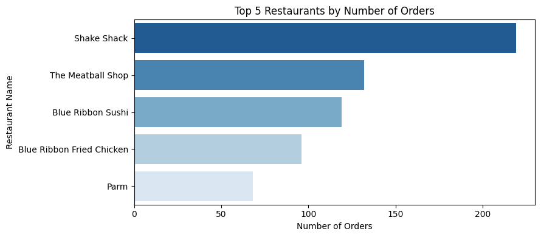

```python
# Top 5 restaurants by order count
top5 = df['restaurant_name'].value_counts().head(5).reset_index()
top5.columns = ['restaurant_name', 'order_count']
print(top5)

# Visualize the data
plt.figure(figsize=(9, 4))
sns.barplot(data=top5, x='order_count', hue='restaurant_name', y='restaurant_name', palette='Blues_r')
plt.title('Top 5 Restaurants by Number of Orders')
plt.xlabel('Number of Orders')
plt.ylabel('Restaurant Name')
plt.tight_layout()
plt.show()
```

### **Question 8**: Which is the most popular cuisine on weekends? [1 mark]

```
Weekend cuisine popularity:
cuisine_type
American          415
Japanese          335
Italian           207
Chinese           163
Mexican            53
Indian             49
Middle Eastern     32
Mediterranean      32
Thai               15
French             13
Korean             11
Southern           11
Spanish            11
Vietnamese          4
Name: count, dtype: int64
```

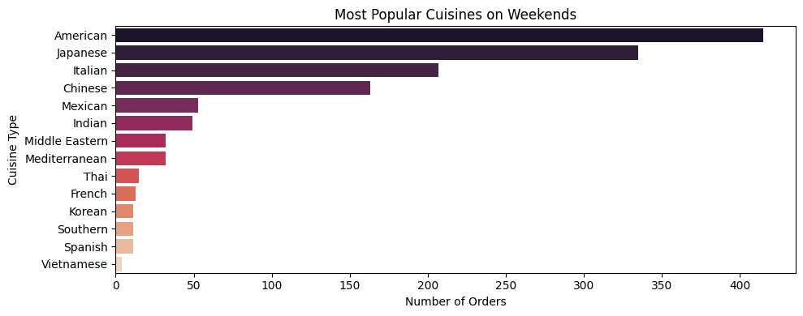

```python
# Most popular cuisine on weekends
weekend_cuisine = df[df['day_of_the_week'] == 'Weekend']['cuisine_type'].value_counts()
print('Weekend cuisine popularity:')
print(weekend_cuisine)

# Visualize
plt.figure(figsize=(10, 4))
sns.barplot(x=weekend_cuisine.values, hue=weekend_cuisine.index, y=weekend_cuisine.index, palette='rocket')
plt.title('Most Popular Cuisines on Weekends')
plt.xlabel('Number of Orders')
plt.ylabel('Cuisine Type')
plt.tight_layout()
plt.show()
```

#### Observations:

- **American** cuisine is the most popular on weekends with 415 orders, followed by Japanese, 335 orders, and Italian, 207 orders.
- Weekend demand for American and Japanese food is significantly higher than other cuisines, making these key categories for weekend promotions.

### **Question 9**: What percentage of the orders cost more than 20 dollars? [2 marks]

```python
# Percentage of orders costing more than $20
orders_above_20 = (df['cost_of_the_order'] > 20).sum()
pct_above_20 = orders_above_20 / len(df) * 100
print(f'Number of orders above $20: {orders_above_20}')
print(f'Percentage of orders above $20: {pct_above_20:.2f}%')
```

```
Number of orders above $20: 555
Percentage of orders above $20: 29.24%
```

#### Observations:

- **555 orders (29.24%)** cost more than $20.
- Nearly 1 in 3 orders exceeds $20, indicating a healthy appetite for higher-value orders — which also generate more revenue (25% commission) for the company.

### **Question 10**: What is the mean order delivery time? [1 mark]

```python
# Mean delivery time
mean_delivery = df['delivery_time'].mean()
print(f'Mean delivery time: {mean_delivery:.2f} minutes')
```

```
Mean delivery time: 24.16 minutes
```

#### Observations:

- The mean delivery time is approximately **24.16 minutes**.
- Combined with an average preparation time of ~27.37 minutes, the average total time from order to door is about **51.5 minutes**.

### **Question 11:** The company has decided to give 20% discount vouchers to the top 3 most frequent customers. Find the IDs of these customers and the number of orders they placed. [1 mark]

```python
# Top 3 most frequent customers
top3_customers = df['customer_id'].value_counts().head(3).reset_index()
top3_customers.columns = ['customer_id', 'order_count']
print('Top 3 most frequent customers:')
print(top3_customers)
```

```
Top 3 most frequent customers:
   customer_id  order_count
0        52832           13
1        47440           10
2        83287            9
```

#### Observations:

- The top 3 customers eligible for the 20% discount voucher are:
  - Customer **52832** — 13 orders
  - Customer **47440** — 10 orders
  - Customer **83287** — 9 orders
- These loyal customers place orders significantly more than average users.

### **Question 12**: Perform a multivariate analysis to explore relationships between the important variables in the dataset. (It is a good idea to explore relations between numerical variables as well as relations between numerical and categorical variables) [10 marks]

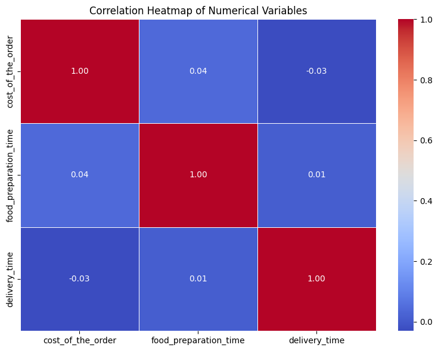

```python
# 1. Correlation heatmap for numerical variables
plt.figure(figsize=(8, 6))
numeric_cols = df[['cost_of_the_order', 'food_preparation_time', 'delivery_time']]
sns.heatmap(numeric_cols.corr(), annot=True, fmt='.2f', cmap='coolwarm', linewidths=0.5)
plt.title('Correlation Heatmap of Numerical Variables')
plt.tight_layout()
plt.show()
```

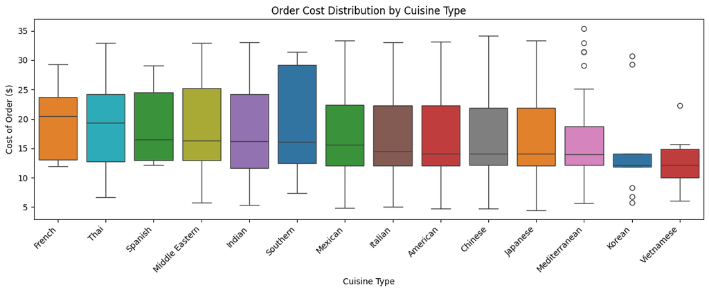

```python
# 2. Cost of order by cuisine type
plt.figure(figsize=(12, 5))
cuisine_order = df.groupby('cuisine_type')['cost_of_the_order'].median().sort_values(ascending=False).index
sns.boxplot(data=df, x='cuisine_type', hue='cuisine_type', y='cost_of_the_order', palette='tab10', order=cuisine_order, legend=False)
plt.title('Order Cost Distribution by Cuisine Type')
plt.xlabel('Cuisine Type')
plt.ylabel('Cost of Order ($)')
plt.xticks(rotation=45, ha='right')
plt.tight_layout()
plt.show()
```

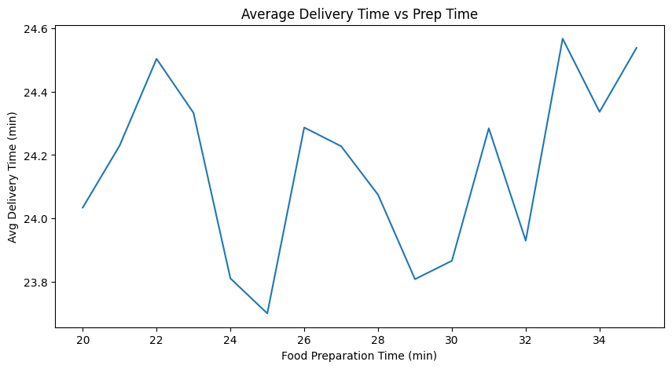

```python
# 3. Food preparation time vs delivery time
plt.figure(figsize=(10,5))
sns.lineplot(data=df, x='food_preparation_time', y='delivery_time',
             estimator='mean', errorbar=None)

plt.title('Average Delivery Time vs Prep Time')
plt.xlabel('Food Preparation Time (min)')
plt.ylabel('Avg Delivery Time (min)')
plt.show()
```

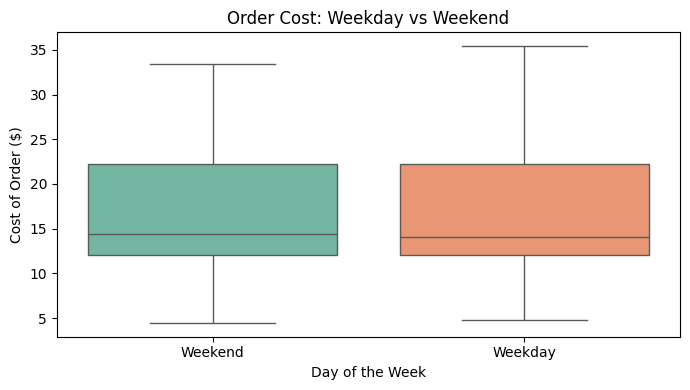

```python
# 4. Cost of order by day of the week
plt.figure(figsize=(7, 4))
sns.boxplot(data=df, x='day_of_the_week', hue= 'day_of_the_week', y='cost_of_the_order', palette='Set2', legend=False)
plt.title('Order Cost: Weekday vs Weekend')
plt.xlabel('Day of the Week')
plt.ylabel('Cost of Order ($)')
plt.tight_layout()
plt.show()
```

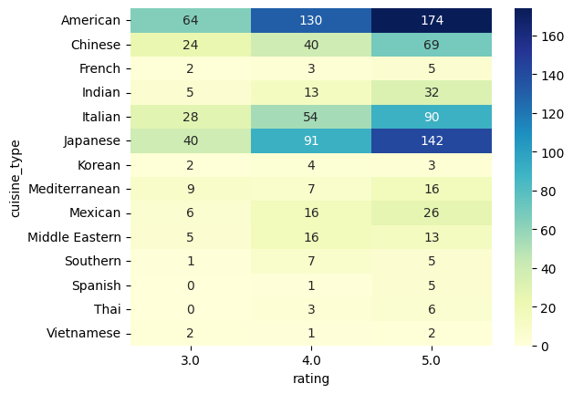

```python
# 5. Rating distribution by cuisine type (only rated orders)
rated_df = df[df['rating'] != 'Not given'].copy()
rated_df['rating'] = rated_df['rating'].astype(float)

pivot = rated_df.groupby(['cuisine_type', 'rating']).size().unstack(fill_value=0)
sns.heatmap(pivot, annot=True, fmt='d', cmap='YlGnBu')
```

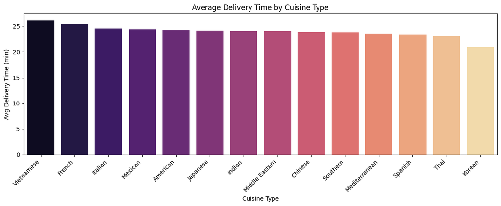

```python
# 6. Average delivery time by cuisine type
avg_delivery = df.groupby('cuisine_type')['delivery_time'].mean().sort_values(ascending=False)
plt.figure(figsize=(12, 5))
sns.barplot(x=avg_delivery.index, hue=avg_delivery.index, y=avg_delivery.values, palette='magma')
plt.title('Average Delivery Time by Cuisine Type')
plt.xlabel('Cuisine Type')
plt.ylabel('Avg Delivery Time (min)')
plt.xticks(rotation=45, ha='right')
plt.tight_layout()
plt.show()
```

#### Observations:

- **Correlation**: Numerical variables show very little correlation with each other — cost, preparation time, and delivery time are largely independent.
- **Cost by Cuisine**: Cuisines like French and Thai tend to have higher median costs, while options such as Korean and Vietnamese generally have lower and more tightly clustered prices. The variation in box size and whiskers that Southern and Middle Eastern indicates greater variabililty in pricing, while others are more consistent.
- **Prep vs Delivery**: No clear linear relationship between prep time and delivery time.
- **Cost by Day**: The cost of orders is very similar on weekdays vs weekends. There is no dramatic difference in spending behavior based on the day. This suggests that day of the week does not strongly influence how much customers spend per order.
- **Rating by Cuisine**: American and Japanese cuisines are the top rated cuisines among customers. American cuisine having 174 5-star ratings, and Japanese cuisine having 142 5-star ratings. Overall, there are positive customer experience having most of the ratings in the 4- and 5-star rating category for those who rated the experience. Cuisines with few ratings make it difficult to draw any data driven conclusions about their performance.
- **Delivery Time by Cuisine**: Delivery times have little to no variation across all cuisine types. Vietnamese has the longest average delivery time and Korean the shortest. We can assume that delivery speed is not significantly influenced by cuisine type.

### **Question 13:** The company wants to provide a promotional offer in the advertisement of the restaurants. The condition to get the offer is that the restaurants must have a rating count of more than 50 and the average rating should be greater than 4. Find the restaurants fulfilling the criteria to get the promotional offer. [3 marks]

```python
# Filter out unrated orders and convert rating to numeric
rated_df = df[df['rating'] != 'Not given'].copy()
rated_df['rating'] = rated_df['rating'].astype(float)

# Group by restaurant and compute rating count and average rating
promo_df = rated_df.groupby('restaurant_name').agg(
    rating_count=('rating', 'count'),
    avg_rating=('rating', 'mean')
).reset_index()

# Apply the promotional criteria
promo_eligible = promo_df[(promo_df['rating_count'] > 50) & (promo_df['avg_rating'] > 4)]
promo_eligible = promo_eligible.sort_values('avg_rating', ascending=False).reset_index(drop=True)
print('Restaurants eligible for promotional offer:')
print(promo_eligible)
```

```
Restaurants eligible for promotional offer:
             restaurant_name  rating_count  avg_rating
0          The Meatball Shop            84    4.511905
1  Blue Ribbon Fried Chicken            64    4.328125
2                Shake Shack           133    4.278195
3          Blue Ribbon Sushi            73    4.219178
```

#### Observations:

- **4 restaurants** meet the promotional criteria (>50 ratings AND avg rating >4):
  1. **The Meatball Shop** — avg rating 4.51, 84 ratings
  2. **Blue Ribbon Fried Chicken** — avg rating 4.33, 64 ratings
  3. **Shake Shack** — avg rating 4.28, 133 ratings
  4. **Blue Ribbon Sushi** — avg rating 4.22, 73 ratings
- Notably, these are also among the top restaurants by order volume, confirming that popularity and quality align for these outlets.

### **Question 14:** The company charges the restaurant 25% on the orders having cost greater than 20 dollars and 15% on the orders having cost greater than 5 dollars. Find the net revenue generated by the company across all orders. [3 marks]

```python
# Define commission function
def calculate_commission(cost):
    if cost > 20:
        return cost * 0.25
    elif cost > 5:
        return cost * 0.15
    else:
        return 0

# Apply to all orders in the dataset
df['commission'] = df['cost_of_the_order'].apply(calculate_commission)

# Net revenue overall
net_revenue = df['commission'].sum()
print(f'Net revenue generated by the company: ${net_revenue:.2f}')

# Breakdown of net revenue by comission percentage
above_20 = df[df['cost_of_the_order'] > 20]['commission'].sum()
between_5_20 = df[(df['cost_of_the_order'] > 5) & (df['cost_of_the_order'] <= 20)]['commission'].sum()
print(f'Revenue from orders > $20 (25% commission): ${above_20:.2f}')
print(f'Revenue from orders $5-$20 (15% commission): ${between_5_20:.2f}')
```

```
Net revenue generated by the company: $6166.30
Revenue from orders > $20 (25% commission): $3688.73
Revenue from orders $5-$20 (15% commission): $2477.58
```

#### Observations:

- The **total net revenue** generated by FoodHub across all orders is **$6,166.30**.
- Orders above $20 (25% commission tier) contribute more per-order revenue than the $5–$20 tier.
- Encouraging higher-value orders could meaningfully grow platform revenue.

### **Question 15:** The company wants to analyze the total time required to deliver the food. What percentage of orders take more than 60 minutes to get delivered from the time the order is placed? (The food has to be prepared and then delivered.) [2 marks]

```python
# Total delivery time = food preparation + delivery
df['total_time'] = df['food_preparation_time'] + df['delivery_time']

# Orders exceeding 60 minutes
orders_above_60 = (df['total_time'] > 60).sum()
pct_above_60 = orders_above_60 / len(df) * 100
print(f'Number of orders taking more than 60 minutes: {orders_above_60}')
print(f'Percentage: {pct_above_60:.2f}%')
```

```
Number of orders taking more than 60 minutes: 200
Percentage: 10.54%
```

#### Observations:

- **200 orders (10.54%)** take more than 60 minutes from order placement to delivery.
- While the majority of orders are delivered within the hour, 1 in 10 orders exceeds this threshold — these cases likely lead to customer dissatisfaction and warrant investigation.

### **Question 16:** The company wants to analyze the delivery time of the orders on weekdays and weekends. How does the mean delivery time vary during weekdays and weekends? [2 marks]

```
Mean delivery time by day type:
day_of_the_week
Weekday    28.34
Weekend    22.47
Name: delivery_time, dtype: float64
```

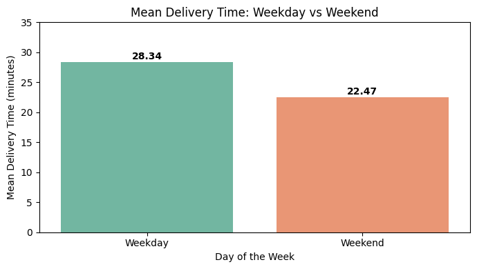

```python
# Mean delivery time by day type
mean_delivery_day = df.groupby('day_of_the_week')['delivery_time'].mean()
print('Mean delivery time by day type:')
print(mean_delivery_day.round(2))

# Visualize
plt.figure(figsize=(7, 4))
sns.barplot(x=mean_delivery_day.index, hue=mean_delivery_day.index, y=mean_delivery_day.values, palette='Set2', legend=False)
plt.title('Mean Delivery Time: Weekday vs Weekend')
plt.xlabel('Day of the Week')
plt.ylabel('Mean Delivery Time (minutes)')
plt.ylim(0, 35)
for i, v in enumerate(mean_delivery_day.values):
    plt.text(i, v + 0.5, f'{v:.2f}', ha='center', fontweight='bold')
plt.tight_layout()
plt.show()
```

#### Observations:

- **Weekday** mean delivery time: **28.34 minutes**
- **Weekend** mean delivery time: **22.47 minutes**
- Delivery is notably **faster on weekends** about ~6 minutes faster on average. This could be due to more delivery drivers being available on weekends, or restaurants being better staffed, resulting in quicker order fulfillment.
- Despite faster delivery on weekends, the overall order volume is much higher, suggesting efficient operations on peak days.

### Recommendations:

- **Improve the rating response rate**: With 38.78% of orders unrated, the company is missing valuable feedback. Implement in-app reminders or small loyalty point incentives to encourage customers to submit ratings after delivery.
- **Invest in weekday operations**: Weekday orders are far fewer (547 vs 1,351 on weekends) yet take longer to deliver. Targeted weekday promotions (e.g., lunch deals, office catering bundles) could boost order volume and amortize fixed delivery costs.
- **Focus marketing on top cuisines**: American, Japanese, and Italian cuisines account for the majority of orders. Co-marketing campaigns with top-performing restaurants in these categories (especially the 4 promo-eligible ones) can amplify platform visibility.
- **Address long-delivery orders**: The ~10.54% of orders taking >60 minutes are a churn risk. Real-time delay notifications, guaranteed delivery-time promises, or automatic discounts for late orders can improve customer retention.
- **Promote high-value orders**: Since orders >$20 generate 25% commission (vs 15%), introducing bundle deals or family meal packages could shift the order cost distribution upward, increasing company revenue per order.
- **Expand high-rating restaurant partnerships**: The 4 promo-eligible restaurants have strong track records. Exclusive deals, featured placement in the app, or co-branded offers with these restaurants can leverage their quality reputations to attract new customers.